# Lab3

Javier Patrón

2023-01-25

## Lab 3: Predicting the age of abalone

Abalones are marine snails. Their flesh is widely considered to be a desirable food, and is consumed raw or cooked by a variety of cultures. The age of abalone is determined by cutting the shell through the cone, staining it, and counting the number of rings through a microscope – a boring and time-consuming task. Other measurements, which are easier to obtain, are used to predict the age.

The data set provided includes variables related to the sex, physical dimensions of the shell, and various weight measurements, along with the number of rings in the shell. Number of rings is the stand-in here for age.

### Data Exploration

Pull the abalone data from Github and take a look at it.

```r
abdat <- dat <- read_csv(file = "https://raw.githubusercontent.com/MaRo406/eds-232-machine-learning/main/data/abalone-data.csv")
```

```
## ──────────────────────────────────────────────────────── Delimiter: "," chr
## (1): Sex dbl (9): ...1, Length, Diameter, Height, Whole_weight, Shucked_weight,
## Visce...
```

```r
glimpse(abdat)
```

```
## Rows: 4,177
## Columns: 10
## $ ...1           <dbl> 1, 2, 3, 4, 5, 6, 7, 8, 9, 10, 11, 12, 13, 14, 15, 16, …
## $ Sex            <chr> "M", "M", "F", "M", "I", "I", "F", "F", "M", "F", "F", …
## $ Length         <dbl> 0.455, 0.350, 0.530, 0.440, 0.330, 0.425, 0.530, 0.545,…
## $ Diameter       <dbl> 0.365, 0.265, 0.420, 0.365, 0.255, 0.300, 0.415, 0.425,…
## $ Height         <dbl> 0.095, 0.090, 0.135, 0.125, 0.080, 0.095, 0.150, 0.125,…
## $ Whole_weight   <dbl> 0.5140, 0.2255, 0.6770, 0.5160, 0.2050, 0.3515, 0.7775,…
## $ Shucked_weight <dbl> 0.2245, 0.0995, 0.2565, 0.2155, 0.0895, 0.1410, 0.2370,…
## $ Viscera_weight <dbl> 0.1010, 0.0485, 0.1415, 0.1140, 0.0395, 0.0775, 0.1415,…
## $ Shell_weight   <dbl> 0.150, 0.070, 0.210, 0.155, 0.055, 0.120, 0.330, 0.260,…
## $ Rings          <dbl> 15, 7, 9, 10, 7, 8, 20, 16, 9, 19, 14, 10, 11, 10, 10, …
```

### Data Splitting

- *Question 1*. Split the data into training and test sets. Use a 70/30 training/test split.

```r
abalone_split <- initial_split(data = abdat, prop = .70)
```

We’ll follow our text book’s lead and use the caret package in our approach to this task. We will use the glmnet package in order to perform ridge regression and the lasso. The main function in this package is glmnet(), which can be used to fit ridge regression models, lasso models, and more. In particular, we must pass in an x matrix of predictors as well as a y outcome vector , and we do not use the y∼x syntax.

### Fit a ridge regression model

- *Question 2*. Use the model.matrix() function to create a predictor matrix, x, and assign the Rings variable to an outcome vector, y.

```r
X = model.matrix(data = abdat, Rings ~ . )
Y = log(abdat$Rings)
```

- *Question 3*. Fit a ridge model (controlled by the alpha parameter) using the glmnet() function. Make a plot showing how the estimated coefficients change with lambda. (Hint: You can call plot() directly on the glmnet() objects).

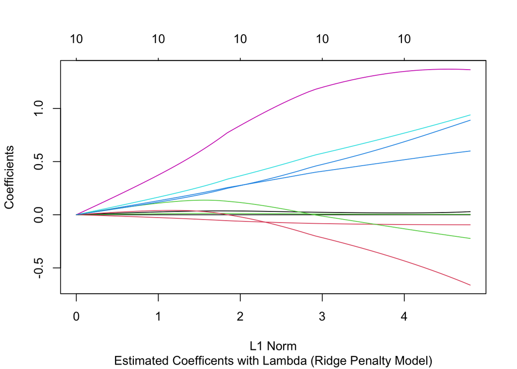

```r
coefficient <- glmnet(x = X,
       y = Y,
       alpha = 0) |>
  plot(sub = "Estimated Coefficents with Lambda (Ridge Penalty Model)")
```

### Using *k*-fold cross validation resampling and tuning our models

In lecture we learned about two methods of estimating our model’s generalization error by resampling, cross validation and bootstrapping. We’ll use the *k*-fold cross validation method in this lab. Recall that lambda is a tuning parameter that helps keep our model from over-fitting to the training data. Tuning is the process of finding the optima value of lamba.

- *Question 4*. This time fit a ridge regression model and a lasso model, both with using cross validation. The glmnet package kindly provides a cv.glmnet() function to do this (similar to the glmnet() function that we just used). Use the alpha argument to control which type of model you are running. Plot the results.

Ridge Penalty Model

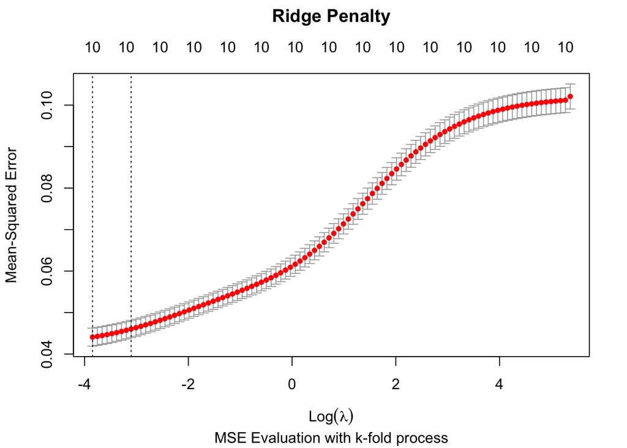

```r
ridge <- cv.glmnet(x = X, y = Y, alpha = 0)

plot(ridge, main = "Ridge Penalty\n\n",
     sub = "MSE Evaluation with k-fold process")
```

```r
min(ridge$cvm)
```

```
## [1] 0.0440769
```

```r
ridge$lambda.min
```

```
## [1] 0.02135152
```

Lasso Penalty Model

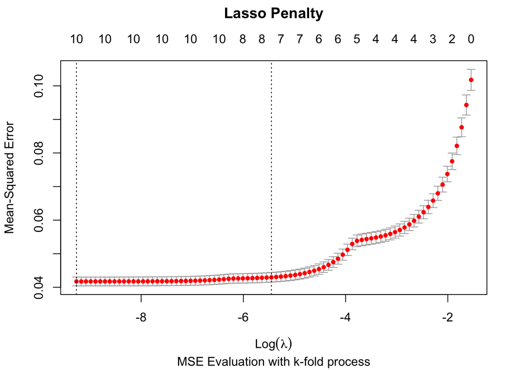

```r
lasso <- cv.glmnet(x = X,
          y = Y,
          alpha = 1)

plot(lasso,
       main = "Lasso Penalty\n\n",
       sub = "MSE Evaluation with k-fold process")
```

```r
min(lasso$cvm)
```

```
## [1] 0.04174367
```

```r
lasso$lambda.min
```

```
## [1] 9.460052e-05
```

- *Question 5*. Interpret the graphs. What is being show on the axes here? How does the performance of the models change with the value of lambda?

*Response: On one hand we have the Ridge Penalty Model, which has a constant number of features (variables) on the top axis of the graph. Showing that the Penalty is affecting all 10 features constantly with an increasing lambda. As we increase Lambda the MSE increases making an slight S shape curve showing that the “optimal” area of the model is with the lower lambda (-4 to -3).*

*On the other hand, the Lasso Penalty Model decreases in number of features in the top of the graph making the model simpler as you increase the lambda. It can be seen that around the -5 lambda the model MSE starts to increase significantly making the model less confident.*

- *Question 6*. Inspect the ridge model object you created with cv.glmnet(). The $cvm column shows the MSEs for each cv fold. What is the minimum MSE? What is the value of lambda associated with this MSE minimum?

```r
#Some wrangling for the Ridge model results
#Minimum MSE value
print(paste("The minimum MSE value for the Ridge Penalty is:", round(min(ridge$cvm),5), "and the associated lambda value is", round(ridge$lambda.min,5)))
```

```
## [1] "The minimum MSE value for the Ridge Penalty is: 0.04408 and the associated lambda value is 0.02135"
```

```r
if (min(ridge$cvm) < min(lasso$cvm)){
  print("The mean squared error of the Ridge Penalty is smaller than the Lasso Penaly")
} else {
  print("The mean squared error of the Lasso Penalty is smaller than the Ridge Penaly")
}
```

```
## [1] "The mean squared error of the Lasso Penalty is smaller than the Ridge Penaly"
```

- *Question 7*. Do the same for the lasso model. What is the minimum MSE? What is the value of lambda associated with this MSE minimum?

```r
#Some wrangling for the Lasso model results
#Minimum MSE value
print(paste("The minimum MSE value for the Lasso Penalty is:", round(min(lasso$cvm),5)))
```

```
## [1] "The minimum MSE value for the Lasso Penalty is: 0.04174"
```

```r
print(paste("The associated lambda value for the minimum MSE on the Lasso pensalty graph is", round(lasso$lambda.min,5)))
```

```
## [1] "The associated lambda value for the minimum MSE on the Lasso pensalty graph is 9e-05"
```

Data scientists often use the “one-standard-error” rule when tuning lambda to select the best model. This rule tells us to pick the most parsimonious model (fewest number of predictors) while still remaining within one standard error of the overall minimum cross validation error. The cv.glmnet() model object has a column that automatically finds the value of lambda associated with the model that produces an MSE that is one standard error from the MSE minimum ($lambda.1se).

- *Question 8.* Find the number of predictors associated with this model (hint: the $nzero is the # of predictors column). *Response: The total number of predictors for the lasso model is 7.*

```r
#lasso$nzero[lasso$lambda == lasso$lambda.min]
lasso$nzero[lasso$lambda == lasso$lambda.1se]
```

```
## s42
##   7
```

- **Question 9.** Which regularized regression worked better for this task, ridge or lasso? Explain your answer.